# L03 Data Transformation

Data Science 1 with R (STAT 301-1)

Author

Ryan Nguyen

## Load packages

```r
# Loading package(s)
library(dplyr, quietly = T)
library(nycflights13)
library(ggplot2)
```

## Datasets

This lab utilizes the `flights` dataset contained in the `nycflights13` package. Documentation/codebook can be accessed with `?fllights`, provided the `nycflights13` package has been installed and then loaded into the current R session.

## Exercises

### Exercise 1

Why does this code not work?

```r
my_variable <- 10
my_varıable
```

```
#> Error: object 'my_varıable' not found
```

Look carefully! This may seem like an exercise in pointlessness, but training your brain to notice even the tiniest difference will pay off when programming.

**ANSWER:** This code does not work because there is a typo with the ‘i’ in ‘my_variable’. It cannot find the second thing printed because it does not exist/has not been assigned.

### Exercise 2

Tweak each of the following R commands so that they run correctly:

```r
# Command 1
ggplot(data = mpg) +
  geom_point(mapping = aes(x = "displ", y = "hwy"))

# Command 2
filter(mpg, cyl == 8)

# Command 3
filter(diamonds, carat > 3)
```

### Exercise 3

Find all flights that:

1. Had an arrival delay of two or more hours
2. Flew to Houston (`IAH` or `HOU`)
3. Were operated by United, American, or Delta
4. Departed in summer (July, August, and September)
5. Arrived more than two hours late, but didn’t leave late
6. Were delayed by at least an hour, but made up over 30 minutes in flight
7. Departed between midnight and 6am (inclusive)

**ANSWERS:**

```r
# part a
flights %>%
  filter(arr_delay >= 120) %>%
  head()
```

```
# A tibble: 6 × 19
   year month   day dep_time sched_dep…¹ dep_d…² arr_t…³ sched…⁴ arr_d…⁵ carrier
  <int> <int> <int>    <int>       <int>   <dbl>   <int>   <int>   <dbl> <chr>
1  2013     1     1      811         630     101    1047     830     137 MQ
2  2013     1     1      848        1835     853    1001    1950     851 MQ
3  2013     1     1      957         733     144    1056     853     123 UA
4  2013     1     1     1114         900     134    1447    1222     145 UA
5  2013     1     1     1505        1310     115    1638    1431     127 EV
6  2013     1     1     1525        1340     105    1831    1626     125 B6
# … with 9 more variables: flight <int>, tailnum <chr>, origin <chr>,
#   dest <chr>, air_time <dbl>, distance <dbl>, hour <dbl>, minute <dbl>,
#   time_hour <dttm>, and abbreviated variable names ¹sched_dep_time,
#   ²dep_delay, ³arr_time, ⁴sched_arr_time, ⁵arr_delay
```

```r
# part b
flights %>%
  filter(dest == "IAH" | dest == "HOU")
```

```
# A tibble: 9,313 × 19
    year month   day dep_time sched_de…¹ dep_d…² arr_t…³ sched…⁴ arr_d…⁵ carrier
   <int> <int> <int>    <int>      <int>   <dbl>   <int>   <int>   <dbl> <chr>
 1  2013     1     1      517        515       2     830     819      11 UA
 2  2013     1     1      533        529       4     850     830      20 UA
 3  2013     1     1      623        627      -4     933     932       1 UA
 4  2013     1     1      728        732      -4    1041    1038       3 UA
 5  2013     1     1      739        739       0    1104    1038      26 UA
 6  2013     1     1      908        908       0    1228    1219       9 UA
 7  2013     1     1     1028       1026       2    1350    1339      11 UA
 8  2013     1     1     1044       1045      -1    1352    1351       1 UA
 9  2013     1     1     1114        900     134    1447    1222     145 UA
10  2013     1     1     1205       1200       5    1503    1505      -2 UA
# … with 9,303 more rows, 9 more variables: flight <int>, tailnum <chr>,
#   origin <chr>, dest <chr>, air_time <dbl>, distance <dbl>, hour <dbl>,
#   minute <dbl>, time_hour <dttm>, and abbreviated variable names
#   ¹sched_dep_time, ²dep_delay, ³arr_time, ⁴sched_arr_time, ⁵arr_delay
```

```r
# part c
flights %>%
  filter(carrier == "UA" | carrier == "AA" | carrier == "DL")
```

```
# A tibble: 139,504 × 19
    year month   day dep_time sched_de…¹ dep_d…² arr_t…³ sched…⁴ arr_d…⁵ carrier
   <int> <int> <int>    <int>      <int>   <dbl>   <int>   <int>   <dbl> <chr>
 1  2013     1     1      517        515       2     830     819      11 UA
 2  2013     1     1      533        529       4     850     830      20 UA
 3  2013     1     1      542        540       2     923     850      33 AA
 4  2013     1     1      554        600      -6     812     837     -25 DL
 5  2013     1     1      554        558      -4     740     728      12 UA
 6  2013     1     1      558        600      -2     753     745       8 AA
 7  2013     1     1      558        600      -2     924     917       7 UA
 8  2013     1     1      558        600      -2     923     937     -14 UA
 9  2013     1     1      559        600      -1     941     910      31 AA
10  2013     1     1      559        600      -1     854     902      -8 UA
# … with 139,494 more rows, 9 more variables: flight <int>, tailnum <chr>,
#   origin <chr>, dest <chr>, air_time <dbl>, distance <dbl>, hour <dbl>,
#   minute <dbl>, time_hour <dttm>, and abbreviated variable names
#   ¹sched_dep_time, ²dep_delay, ³arr_time, ⁴sched_arr_time, ⁵arr_delay
```

```r
# part d
flights %>%
  filter(month == 7 | month == 8 | month == 9)
```

```
# A tibble: 86,326 × 19
    year month   day dep_time sched_de…¹ dep_d…² arr_t…³ sched…⁴ arr_d…⁵ carrier
   <int> <int> <int>    <int>      <int>   <dbl>   <int>   <int>   <dbl> <chr>
 1  2013     7     1        1       2029     212     236    2359     157 B6
 2  2013     7     1        2       2359       3     344     344       0 B6
 3  2013     7     1       29       2245     104     151       1     110 B6
 4  2013     7     1       43       2130     193     322      14     188 B6
 5  2013     7     1       44       2150     174     300     100     120 AA
 6  2013     7     1       46       2051     235     304    2358     186 B6
 7  2013     7     1       48       2001     287     308    2305     243 VX
 8  2013     7     1       58       2155     183     335      43     172 B6
 9  2013     7     1      100       2146     194     327      30     177 B6
10  2013     7     1      100       2245     135     337     135     122 B6
# … with 86,316 more rows, 9 more variables: flight <int>, tailnum <chr>,
#   origin <chr>, dest <chr>, air_time <dbl>, distance <dbl>, hour <dbl>,
#   minute <dbl>, time_hour <dttm>, and abbreviated variable names
#   ¹sched_dep_time, ²dep_delay, ³arr_time, ⁴sched_arr_time, ⁵arr_delay
```

```r
# part e
flights %>%
  filter(arr_delay >= 120 & dep_delay <= 0 )
```

```
# A tibble: 29 × 19
    year month   day dep_time sched_de…¹ dep_d…² arr_t…³ sched…⁴ arr_d…⁵ carrier
   <int> <int> <int>    <int>      <int>   <dbl>   <int>   <int>   <dbl> <chr>
 1  2013     1    27     1419       1420      -1    1754    1550     124 MQ
 2  2013    10     7     1350       1350       0    1736    1526     130 EV
 3  2013    10     7     1357       1359      -2    1858    1654     124 AA
 4  2013    10    16      657        700      -3    1258    1056     122 B6
 5  2013    11     1      658        700      -2    1329    1015     194 VX
 6  2013     3    18     1844       1847      -3      39    2219     140 UA
 7  2013     4    17     1635       1640      -5    2049    1845     124 MQ
 8  2013     4    18      558        600      -2    1149     850     179 AA
 9  2013     4    18      655        700      -5    1213     950     143 AA
10  2013     5    22     1827       1830      -3    2217    2010     127 MQ
# … with 19 more rows, 9 more variables: flight <int>, tailnum <chr>,
#   origin <chr>, dest <chr>, air_time <dbl>, distance <dbl>, hour <dbl>,
#   minute <dbl>, time_hour <dttm>, and abbreviated variable names
#   ¹sched_dep_time, ²dep_delay, ³arr_time, ⁴sched_arr_time, ⁵arr_delay
```

```r
# part f
flights %>%
  filter(dep_delay >= 60, (dep_delay - arr_delay) > 30)
```

```
# A tibble: 1,844 × 19
    year month   day dep_time sched_de…¹ dep_d…² arr_t…³ sched…⁴ arr_d…⁵ carrier
   <int> <int> <int>    <int>      <int>   <dbl>   <int>   <int>   <dbl> <chr>
 1  2013     1     1     2205       1720     285      46    2040     246 AA
 2  2013     1     1     2326       2130     116     131      18      73 B6
 3  2013     1     3     1503       1221     162    1803    1555     128 UA
 4  2013     1     3     1839       1700      99    2056    1950      66 AA
 5  2013     1     3     1850       1745      65    2148    2120      28 AA
 6  2013     1     3     1941       1759     102    2246    2139      67 UA
 7  2013     1     3     1950       1845      65    2228    2227       1 B6
 8  2013     1     3     2015       1915      60    2135    2111      24 9E
 9  2013     1     3     2257       2000     177      45    2224     141 9E
10  2013     1     4     1917       1700     137    2135    1950     105 AA
# … with 1,834 more rows, 9 more variables: flight <int>, tailnum <chr>,
#   origin <chr>, dest <chr>, air_time <dbl>, distance <dbl>, hour <dbl>,
#   minute <dbl>, time_hour <dttm>, and abbreviated variable names
#   ¹sched_dep_time, ²dep_delay, ³arr_time, ⁴sched_arr_time, ⁵arr_delay
```

```r
# part g
flights %>%
  filter(dep_time == 2400 | dep_time <= 600)
```

```
# A tibble: 9,373 × 19
    year month   day dep_time sched_de…¹ dep_d…² arr_t…³ sched…⁴ arr_d…⁵ carrier
   <int> <int> <int>    <int>      <int>   <dbl>   <int>   <int>   <dbl> <chr>
 1  2013     1     1      517        515       2     830     819      11 UA
 2  2013     1     1      533        529       4     850     830      20 UA
 3  2013     1     1      542        540       2     923     850      33 AA
 4  2013     1     1      544        545      -1    1004    1022     -18 B6
 5  2013     1     1      554        600      -6     812     837     -25 DL
 6  2013     1     1      554        558      -4     740     728      12 UA
 7  2013     1     1      555        600      -5     913     854      19 B6
 8  2013     1     1      557        600      -3     709     723     -14 EV
 9  2013     1     1      557        600      -3     838     846      -8 B6
10  2013     1     1      558        600      -2     753     745       8 AA
# … with 9,363 more rows, 9 more variables: flight <int>, tailnum <chr>,
#   origin <chr>, dest <chr>, air_time <dbl>, distance <dbl>, hour <dbl>,
#   minute <dbl>, time_hour <dttm>, and abbreviated variable names
#   ¹sched_dep_time, ²dep_delay, ³arr_time, ⁴sched_arr_time, ⁵arr_delay
```

### Exercise 4

A useful `dplyr` filtering helper is `between()`. Rewrite your code to Exercise 3 (d) using `between()`? If you did use it, then indicate that you did.

**ANSWER:**

```r
d_flight_2 <- filter(flights, between(month, 7, 9))
```

### Exercise 5

How many flights have a missing `dep_time`? What other variables are missing? What might these rows represent?

```r
filter(flights, is.na(dep_time))
```

```
# A tibble: 8,255 × 19
    year month   day dep_time sched_de…¹ dep_d…² arr_t…³ sched…⁴ arr_d…⁵ carrier
   <int> <int> <int>    <int>      <int>   <dbl>   <int>   <int>   <dbl> <chr>
 1  2013     1     1       NA       1630      NA      NA    1815      NA EV
 2  2013     1     1       NA       1935      NA      NA    2240      NA AA
 3  2013     1     1       NA       1500      NA      NA    1825      NA AA
 4  2013     1     1       NA        600      NA      NA     901      NA B6
 5  2013     1     2       NA       1540      NA      NA    1747      NA EV
 6  2013     1     2       NA       1620      NA      NA    1746      NA EV
 7  2013     1     2       NA       1355      NA      NA    1459      NA EV
 8  2013     1     2       NA       1420      NA      NA    1644      NA EV
 9  2013     1     2       NA       1321      NA      NA    1536      NA EV
10  2013     1     2       NA       1545      NA      NA    1910      NA AA
# … with 8,245 more rows, 9 more variables: flight <int>, tailnum <chr>,
#   origin <chr>, dest <chr>, air_time <dbl>, distance <dbl>, hour <dbl>,
#   minute <dbl>, time_hour <dttm>, and abbreviated variable names
#   ¹sched_dep_time, ²dep_delay, ³arr_time, ⁴sched_arr_time, ⁵arr_delay
```

**ANSWER:** There are 8,255 flights missing ‘dep_time’. The other variables missing are ‘dep_delay’, ‘arr_time’, ‘arr_delay’, and ‘air_time’. These rows might represent cancelled flights or flights whose times were not documented.

### Exercise 6

How could you use `arrange()` to sort the dataset so that flights missing `arr_delay` are at the start/top of the tibble/table? *Hint:* Use `is.na()`

```r
flights %>%
  arrange(desc(is.na(arr_delay)))
```

```
# A tibble: 336,776 × 19
    year month   day dep_time sched_de…¹ dep_d…² arr_t…³ sched…⁴ arr_d…⁵ carrier
   <int> <int> <int>    <int>      <int>   <dbl>   <int>   <int>   <dbl> <chr>
 1  2013     1     1     1525       1530      -5    1934    1805      NA MQ
 2  2013     1     1     1528       1459      29    2002    1647      NA EV
 3  2013     1     1     1740       1745      -5    2158    2020      NA MQ
 4  2013     1     1     1807       1738      29    2251    2103      NA UA
 5  2013     1     1     1939       1840      59      29    2151      NA 9E
 6  2013     1     1     1952       1930      22    2358    2207      NA EV
 7  2013     1     1     2016       1930      46      NA    2220      NA EV
 8  2013     1     1       NA       1630      NA      NA    1815      NA EV
 9  2013     1     1       NA       1935      NA      NA    2240      NA AA
10  2013     1     1       NA       1500      NA      NA    1825      NA AA
# … with 336,766 more rows, 9 more variables: flight <int>, tailnum <chr>,
#   origin <chr>, dest <chr>, air_time <dbl>, distance <dbl>, hour <dbl>,
#   minute <dbl>, time_hour <dttm>, and abbreviated variable names
#   ¹sched_dep_time, ²dep_delay, ³arr_time, ⁴sched_arr_time, ⁵arr_delay
```

### Exercise 7

Sort `flights` to find the most delayed flights. Find the flights that left earliest. Name the flight at top of the list (e.g. New York City JFK to Chicago ORD).

```r
flights %>%
  arrange(dep_delay) %>%
  select(dep_delay, origin, flight, dest, time_hour)
```

```
# A tibble: 336,776 × 5
   dep_delay origin flight dest  time_hour
       <dbl> <chr>   <int> <chr> <dttm>
 1       -43 JFK        97 DEN   2013-12-07 21:00:00
 2       -33 LGA      1715 MSY   2013-02-03 20:00:00
 3       -32 LGA      5713 IAD   2013-11-10 14:00:00
 4       -30 LGA      1435 TPA   2013-01-11 19:00:00
 5       -27 LGA       837 DEN   2013-01-29 17:00:00
 6       -26 LGA      3478 DTW   2013-08-09 07:00:00
 7       -25 EWR      4361 TYS   2013-10-23 19:00:00
 8       -25 LGA      4573 DTW   2013-03-30 20:00:00
 9       -24 JFK      3318 BUF   2013-03-02 14:00:00
10       -24 LGA       375 FLL   2013-05-05 09:00:00
# … with 336,766 more rows
```

**ANSWER:** On December 7th, Flight 97 left 43 minutes ahead of schedule traveling from New York City JFK to Denver DEN.

### Exercise 8

Sort flights to find the fastest flights. Name the flight at top of the list (e.g. New York City JFK to Chicago ORD).

```r
flights %>%
  arrange(air_time) %>%
  select(air_time, origin, flight, dest, time_hour)
```

```
# A tibble: 336,776 × 5
   air_time origin flight dest  time_hour
      <dbl> <chr>   <int> <chr> <dttm>
 1       20 EWR      4368 BDL   2013-01-16 13:00:00
 2       20 EWR      4631 BDL   2013-04-13 05:00:00
 3       21 EWR      4276 BDL   2013-12-06 08:00:00
 4       21 EWR      4619 PHL   2013-02-03 21:00:00
 5       21 EWR      4368 BDL   2013-02-05 13:00:00
 6       21 EWR      4619 PHL   2013-02-12 21:00:00
 7       21 LGA      2132 BOS   2013-03-02 15:00:00
 8       21 JFK      3650 PHL   2013-03-08 19:00:00
 9       21 EWR      4118 BDL   2013-03-18 13:00:00
10       21 EWR      4276 BDL   2013-03-19 21:00:00
# … with 336,766 more rows
```

### Exercise 9

Which flights traveled the longest? Which traveled the shortest? Name the flight at top of the list (e.g. New York City JFK to Chicago ORD).

```r
flights %>%
  arrange(distance) %>%
  select(distance, origin, flight, dest, time_hour) %>%
  head(3)
```

```
# A tibble: 3 × 5
  distance origin flight dest  time_hour
     <dbl> <chr>   <int> <chr> <dttm>
1       17 EWR      1632 LGA   2013-07-27 01:00:00
2       80 EWR      3833 PHL   2013-01-03 21:00:00
3       80 EWR      4193 PHL   2013-01-04 12:00:00
```

```r
flights %>%
  arrange(desc(distance)) %>%
  select(distance, origin, flight, dest, time_hour) %>%
  head(3)
```

```
# A tibble: 3 × 5
  distance origin flight dest  time_hour
     <dbl> <chr>   <int> <chr> <dttm>
1     4983 JFK        51 HNL   2013-01-01 09:00:00
2     4983 JFK        51 HNL   2013-01-02 09:00:00
3     4983 JFK        51 HNL   2013-01-03 09:00:00
```

**ANSWER:** Flight 51 traveled the longest, a total of 4983 miles from New York JFK to Honolulu HNL. Flight 1632 traveled the shortest, just 17 miles from Newark EWR to New York LGA.

### Exercise 10

Brainstorm at least 3 ways to select `dep_time`, `dep_delay`, `arr_time`, and `arr_delay` from `flights`. *Hint:* Use helper functions

```r
flights %>%
  select(starts_with("dep") | starts_with ("arr"))
```

```
# A tibble: 336,776 × 4
   dep_time dep_delay arr_time arr_delay
      <int>     <dbl>    <int>     <dbl>
 1      517         2      830        11
 2      533         4      850        20
 3      542         2      923        33
 4      544        -1     1004       -18
 5      554        -6      812       -25
 6      554        -4      740        12
 7      555        -5      913        19
 8      557        -3      709       -14
 9      557        -3      838        -8
10      558        -2      753         8
# … with 336,766 more rows
```

```r
flights %>%
  select("dep_time" | "arr_time" | ends_with ("delay"))
```

```
# A tibble: 336,776 × 4
   dep_time arr_time dep_delay arr_delay
      <int>    <int>     <dbl>     <dbl>
 1      517      830         2        11
 2      533      850         4        20
 3      542      923         2        33
 4      544     1004        -1       -18
 5      554      812        -6       -25
 6      554      740        -4        12
 7      555      913        -5        19
 8      557      709        -3       -14
 9      557      838        -3        -8
10      558      753        -2         8
# … with 336,766 more rows
```

```r
flights %>%
  select("dep_time" | "arr_time" | contains ("dep_delay") | contains ("arr_delay"))
```

```
# A tibble: 336,776 × 4
   dep_time arr_time dep_delay arr_delay
      <int>    <int>     <dbl>     <dbl>
 1      517      830         2        11
 2      533      850         4        20
 3      542      923         2        33
 4      544     1004        -1       -18
 5      554      812        -6       -25
 6      554      740        -4        12
 7      555      913        -5        19
 8      557      709        -3       -14
 9      557      838        -3        -8
10      558      753        -2         8
# … with 336,766 more rows
```

```r
varis <- c("dep_time", "arr_time", "dep_delay", "arr_delay")
flights %>%
  select(any_of(varis))
```

```
# A tibble: 336,776 × 4
   dep_time arr_time dep_delay arr_delay
      <int>    <int>     <dbl>     <dbl>
 1      517      830         2        11
 2      533      850         4        20
 3      542      923         2        33
 4      544     1004        -1       -18
 5      554      812        -6       -25
 6      554      740        -4        12
 7      555      913        -5        19
 8      557      709        -3       -14
 9      557      838        -3        -8
10      558      753        -2         8
# … with 336,766 more rows
```

### Exercise 11

What does the `any_of()` function do? Why might it be helpful in conjunction with the vector below?

```r
vars <- c("year", "month", "day", "dep_delay", "arr_delay")

flights %>%
  select(any_of(vars))
```

```
# A tibble: 336,776 × 5
    year month   day dep_delay arr_delay
   <int> <int> <int>     <dbl>     <dbl>
 1  2013     1     1         2        11
 2  2013     1     1         4        20
 3  2013     1     1         2        33
 4  2013     1     1        -1       -18
 5  2013     1     1        -6       -25
 6  2013     1     1        -4        12
 7  2013     1     1        -5        19
 8  2013     1     1        -3       -14
 9  2013     1     1        -3        -8
10  2013     1     1        -2         8
# … with 336,766 more rows
```

**ANSWER:** The ‘any_of()’ function will take a vector and give you all of the variables listed in it. It is flexible, just checking through all variations. If vars are there will not give error, unlike all_of().

### Exercise 12

Does the result of running the code below surprise you? Which default setting for `contains()` causes this to happen? What should happen if you run the code, but with the default setting changed?

```r
select(flights, contains("TIME"))
```

```
# A tibble: 336,776 × 6
   dep_time sched_dep_time arr_time sched_arr_time air_time time_hour
      <int>          <int>    <int>          <int>    <dbl> <dttm>
 1      517            515      830            819      227 2013-01-01 05:00:00
 2      533            529      850            830      227 2013-01-01 05:00:00
 3      542            540      923            850      160 2013-01-01 05:00:00
 4      544            545     1004           1022      183 2013-01-01 05:00:00
 5      554            600      812            837      116 2013-01-01 06:00:00
 6      554            558      740            728      150 2013-01-01 05:00:00
 7      555            600      913            854      158 2013-01-01 06:00:00
 8      557            600      709            723       53 2013-01-01 06:00:00
 9      557            600      838            846      140 2013-01-01 06:00:00
10      558            600      753            745      138 2013-01-01 06:00:00
# … with 336,766 more rows
```

```r
select(flights, contains("TIME", ignore.case = FALSE))
```

```
# A tibble: 336,776 × 0
```

**ANSWER:** The code does not surprise me. The default setting in ‘contains()’ is ‘ignore.case = TRUE’, meaning that it does not care if the “TIME” is capitalized or not. If we changed the default code to ‘ignore.case = FALSE’, then it will take capitalization into account and not return these columns since they are not capitalized.

### Exercise 13

Currently `dep_time` and `sched_dep_time` are convenient to look at, but hard to compute with because they’re not really continuous numbers. Convert them to a more convenient representation of number of minutes since midnight.

```r
mutate(flights,
       dep_time = (dep_time %/% 100) * 60 + (dep_time %% 100),
       sched_dep_time = (sched_dep_time %/% 100) * 60 + (sched_dep_time %% 100))
```

```
# A tibble: 336,776 × 19
    year month   day dep_time sched_de…¹ dep_d…² arr_t…³ sched…⁴ arr_d…⁵ carrier
   <int> <int> <int>    <dbl>      <dbl>   <dbl>   <int>   <int>   <dbl> <chr>
 1  2013     1     1      317        315       2     830     819      11 UA
 2  2013     1     1      333        329       4     850     830      20 UA
 3  2013     1     1      342        340       2     923     850      33 AA
 4  2013     1     1      344        345      -1    1004    1022     -18 B6
 5  2013     1     1      354        360      -6     812     837     -25 DL
 6  2013     1     1      354        358      -4     740     728      12 UA
 7  2013     1     1      355        360      -5     913     854      19 B6
 8  2013     1     1      357        360      -3     709     723     -14 EV
 9  2013     1     1      357        360      -3     838     846      -8 B6
10  2013     1     1      358        360      -2     753     745       8 AA
# … with 336,766 more rows, 9 more variables: flight <int>, tailnum <chr>,
#   origin <chr>, dest <chr>, air_time <dbl>, distance <dbl>, hour <dbl>,
#   minute <dbl>, time_hour <dttm>, and abbreviated variable names
#   ¹sched_dep_time, ²dep_delay, ³arr_time, ⁴sched_arr_time, ⁵arr_delay
```

### Exercise 14

Compare `air_time` with `arr_time - dep_time`. What do you expect to see? What do you see? What do you need to do to fix it?

```r
mutate(flights,
       time_air = arr_time - dep_time) %>%
  select(flight, air_time, time_air, arr_time, dep_time)
```

```
# A tibble: 336,776 × 5
   flight air_time time_air arr_time dep_time
    <int>    <dbl>    <int>    <int>    <int>
 1   1545      227      313      830      517
 2   1714      227      317      850      533
 3   1141      160      381      923      542
 4    725      183      460     1004      544
 5    461      116      258      812      554
 6   1696      150      186      740      554
 7    507      158      358      913      555
 8   5708       53      152      709      557
 9     79      140      281      838      557
10    301      138      195      753      558
# … with 336,766 more rows
```

**ANSWER:** When subtracting departure time from arrival time, one would expect to find the exact air time for a specific flight. However, it is important to remember that the arrival and departure times are currently in HHMM format, meaning they are not in numerical minutes. For example, if a flight departed at 8:30 and arrived at 9:30, it would compute 100 because it takes 930-830, when in reality the flight time was 60 minutes. Thus, we have to convert the arrival and departure times into numerical values from midnight before subtracting them, which would then give us the air time. Additionally, some values may be off because it does not take into account time zones, as well as planes arriving past midnight.

### Exercise 15

Compare `dep_time`, `sched_dep_time`, and `dep_delay`. How would you expect those three numbers to be related?

```r
flights %>%
  mutate(time_dep = sched_dep_time + dep_delay) %>%
  select (dep_time, time_dep, sched_dep_time, dep_delay)
```

```
# A tibble: 336,776 × 4
   dep_time time_dep sched_dep_time dep_delay
      <int>    <dbl>          <int>     <dbl>
 1      517      517            515         2
 2      533      533            529         4
 3      542      542            540         2
 4      544      544            545        -1
 5      554      594            600        -6
 6      554      554            558        -4
 7      555      595            600        -5
 8      557      597            600        -3
 9      557      597            600        -3
10      558      598            600        -2
# … with 336,766 more rows
```

**ANSWER:** I would expect that ‘dep_time’ is equal to ‘sched_dep_time’ plus ‘dep_delay’, since the time of actual departure is the scheduled departure time plus the amount of delay. However, this might not always be correct, again, since the times are in HHMM format. This means that when a flight is leaving at 6:00 and leaves 2 minutes early, the calculation would output 598, when in reality, it departed at 5:58, or 558.

### Exercise 16

Find the 10 most delayed flights using the `min_rank()` function.

```r
filter(flights, min_rank(desc(arr_delay))<=10)
```

```
# A tibble: 10 × 19
    year month   day dep_time sched_de…¹ dep_d…² arr_t…³ sched…⁴ arr_d…⁵ carrier
   <int> <int> <int>    <int>      <int>   <dbl>   <int>   <int>   <dbl> <chr>
 1  2013     1     9      641        900    1301    1242    1530    1272 HA
 2  2013     1    10     1121       1635    1126    1239    1810    1109 MQ
 3  2013    12     5      756       1700     896    1058    2020     878 AA
 4  2013     3    17     2321        810     911     135    1020     915 DL
 5  2013     4    10     1100       1900     960    1342    2211     931 DL
 6  2013     5     3     1133       2055     878    1250    2215     875 MQ
 7  2013     6    15     1432       1935    1137    1607    2120    1127 MQ
 8  2013     7    22      845       1600    1005    1044    1815     989 MQ
 9  2013     7    22     2257        759     898     121    1026     895 DL
10  2013     9    20     1139       1845    1014    1457    2210    1007 AA
# … with 9 more variables: flight <int>, tailnum <chr>, origin <chr>,
#   dest <chr>, air_time <dbl>, distance <dbl>, hour <dbl>, minute <dbl>,
#   time_hour <dttm>, and abbreviated variable names ¹sched_dep_time,
#   ²dep_delay, ³arr_time, ⁴sched_arr_time, ⁵arr_delay
```

### Exercise 17

Come up with another approach that will give you the same output as `not_cancelled %>% count(dest)` and `not_cancelled %>% count(tailnum, wt = distance)` (without using `count()`). Dataset `not_cancelled` was created in this section of the book, but for your convenience the code is provided.

```r
not_cancelled <- flights %>%
  filter(!is.na(dep_delay), !is.na(arr_delay))

not_cancelled %>% count(tailnum, wt = distance)
```

```
# A tibble: 4,037 × 2
   tailnum      n
   <chr>    <dbl>
 1 D942DN    3418
 2 N0EGMQ  239143
 3 N10156  109664
 4 N102UW   25722
 5 N103US   24619
 6 N104UW   24616
 7 N10575  139903
 8 N105UW   23618
 9 N107US   21677
10 N108UW   32070
# … with 4,027 more rows
```

```r
not_cancelled %>%
  group_by(tailnum) %>%
  summarise(n = sum(distance))
```

```
# A tibble: 4,037 × 2
   tailnum      n
   <chr>    <dbl>
 1 D942DN    3418
 2 N0EGMQ  239143
 3 N10156  109664
 4 N102UW   25722
 5 N103US   24619
 6 N104UW   24616
 7 N10575  139903
 8 N105UW   23618
 9 N107US   21677
10 N108UW   32070
# … with 4,027 more rows
```

### Exercise 18

Look at the number of cancelled flights per day. Is there a pattern? Is the proportion of cancelled flights related to the average delay?

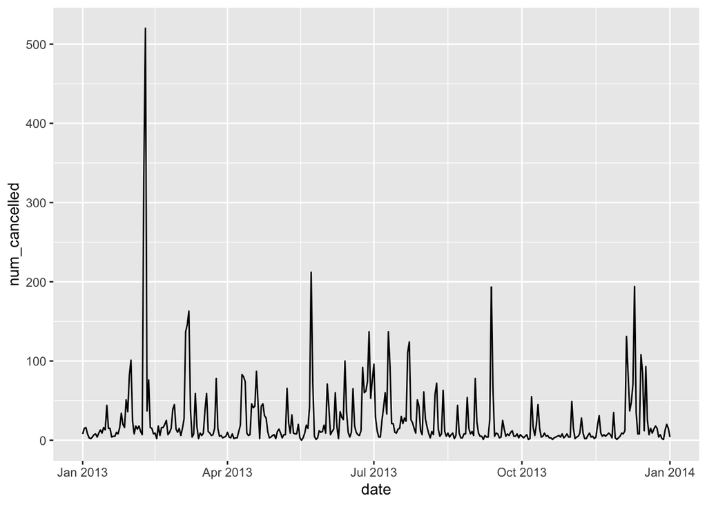

```r
flights_cancelled <- flights %>%
  mutate(date = as.Date(time_hour)) %>%
  group_by(date) %>%
  summarize(num_cancelled = sum (is.na(arr_delay)))

ggplot(flights_cancelled, aes(x = date, y = num_cancelled)) +
  geom_line()
```

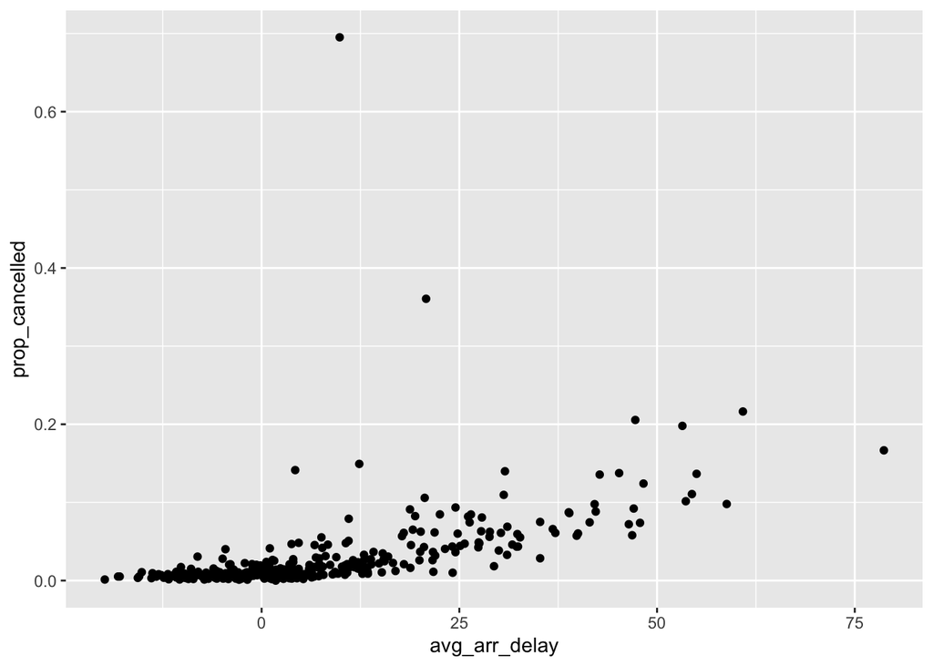

```r
flights_prop <- flights %>%
  mutate(date = as.Date(time_hour),
         cancelled = (is.na(arr_delay) | is.na(dep_delay))) %>%
  group_by(date) %>%
  summarise(prop_cancelled = mean(cancelled),
    avg_arr_delay = mean(arr_delay, na.rm = TRUE))

ggplot(flights_prop, aes(x = avg_arr_delay, y = prop_cancelled)) +
  geom_point()
```

**ANSWER:** When looking at the number of cancelled flights per day, there does not seem to be a large pattern. The number of flights cancelled spikes up and down, however there was a large spike near February or March of 2013. This might be from snow storms of inclement weather. However, there does seem to be a positive relationship between the proportion of cancelled flights to the average delay, as average delays increase, so do the proportion of cancelled flights. This makes sense as things are more delayed, the more likely it is that it is cancelled.

### Exercise 19

Which plane (`tailnum`) has the worst on-time record?

```r
flights %>%
  filter(!is.na(arr_delay) | !is.na(dep_delay)) %>%
  group_by(tailnum) %>%
  mutate(flights_on_time = (arr_delay < 0)) %>%
  summarize(flights_on_time = mean(flights_on_time),
            n=n()) %>%
  filter(n > 15) %>%
  arrange(flights_on_time)
```

```
# A tibble: 3,253 × 3
   tailnum flights_on_time     n
   <chr>             <dbl> <int>
 1 N290AT            0.125    16
 2 N326AT            0.176    17
 3 N338AT            0.188    16
 4 N634MQ            0.188    16
 5 N913JB            0.188    16
 6 N988AT            0.2      35
 7 N924AT            0.208    24
 8 N521LR            0.235    17
 9 N969AT            0.235    34
10 N673UA            0.25     16
# … with 3,243 more rows
```

The plane (‘tailnum’) with the worst on-time record, which I interpreted as the plane with the lowest proportion of on-time flights, was N290AT, with a proportion of .125 flights on time, giving it the worst on-time record. I filtered out flights that flew less than 15 flights as well, to account for the fact that some flights will have a 0% on time record if they have flown so little flights.

### Exercise 20

For each destination, compute the total minutes of delay. For each flight, compute the proportion of the total delay for its destination.

```r
flights %>%
  filter(arr_delay > 0, !is.na(arr_delay)) %>%
  group_by(dest) %>%
  mutate(total_delay = sum(arr_delay),
            prop_delay = arr_delay/total_delay) %>%
  select(tailnum, arr_delay, dest, total_delay, prop_delay, time_hour)
```

```
# A tibble: 133,004 × 6
# Groups:   dest [103]
   tailnum arr_delay dest  total_delay prop_delay time_hour
   <chr>       <dbl> <chr>       <dbl>      <dbl> <dttm>
 1 N14228         11 IAH         99391  0.000111  2013-01-01 05:00:00
 2 N24211         20 IAH         99391  0.000201  2013-01-01 05:00:00
 3 N619AA         33 MIA        140424  0.000235  2013-01-01 05:00:00
 4 N39463         12 ORD        283046  0.0000424 2013-01-01 05:00:00
 5 N516JB         19 FLL        202605  0.0000938 2013-01-01 06:00:00
 6 N3ALAA          8 ORD        283046  0.0000283 2013-01-01 06:00:00
 7 N29129          7 LAX        203226  0.0000344 2013-01-01 06:00:00
 8 N3DUAA         31 DFW        110009  0.000282  2013-01-01 06:00:00
 9 N542MQ         12 ATL        300299  0.0000400 2013-01-01 06:00:00
10 N730MQ         16 DTW        138258  0.000116  2013-01-01 06:00:00
# … with 132,994 more rows
```

### Exercise 21

For each plane, count the number of flights before the first delay of greater than 1 hour.

```r
not_cancelled <- flights %>%
  filter(!is.na(dep_delay), !is.na(arr_delay))

not_cancelled %>%
  select(tailnum, year, month, day, dep_time, arr_delay) %>%
  arrange(tailnum, year, month, day, dep_time) %>%
  group_by(tailnum) %>%
  mutate(
    flights_before_delay = cumsum(arr_delay > 60)) %>%
  summarise(n_flights = sum(flights_before_delay == 0))
```

```
# A tibble: 4,037 × 2
   tailnum n_flights
   <chr>       <int>
 1 D942DN          0
 2 N0EGMQ          0
 3 N10156          9
 4 N102UW         25
 5 N103US         46
 6 N104UW          3
 7 N10575          0
 8 N105UW         22
 9 N107US         20
10 N108UW         36
# … with 4,027 more rows
```